# STATS 326/786

# Comment on the most common and least common game days:

> Total possible marks for **Problem 1**: 45 Marks

# Problem 2: Monthly average temperatures in Auckland

The data set `auckland_temps.csv` contains the monthly average temperatures in Auckland from July 1994 until January 2024. [Data source: https://cliflo.niwa.co.nz]

> 1. 5 Marks
> - Read in the data using `read_csv` (don’t use `read.csv`).
> - Convert the `Month` variable into the correct date format. Hint: You will need to use a function from the `tsibble` package.
> - Coerce your `tibble` to a `tsibble` object with `Month` as the index.

```r
auckland_temps <- read.csv("auckland_temps.csv")

auckland_temps <- auckland_temps %>%
  mutate(Month = yearmonth(Month)) %>%
  as_tsibble(index = Month)

print(auckland_temps, n = 10)
```

```
## # A tsibble: 355 x 2 [1M]
##       Month Temperature
##       <mth>       <dbl>
##  1 1994 Jul        10.5
##  2 1994 Aug        11
##  3 1994 Sep        12.2
##  4 1994 Oct        13.6
##  5 1994 Nov        15.7
##  6 1994 Dec        18.7
##  7 1995 Jan        19.7
##  8 1995 Feb        20.5
##  9 1995 Mar        19
## 10 1995 Apr        18.2
## # ℹ 345 more rows
```

> 2. 7 Marks
> - Create a time plot, seasonal plot, and subseries plot of the data.
> - Comment on the seasonality in the plots. Which month has the highest average temperatures, and which month has the lowest?
> - Comment on whether there is a trend in the data and if so, in what direction.

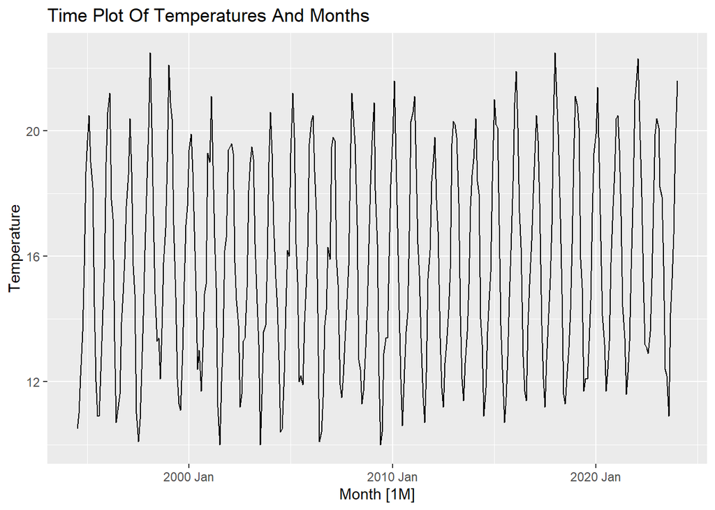

```r
auckland_temps %>%
  autoplot(Temperature) +
  labs(title = "Time Plot Of Temperatures And Months")
```

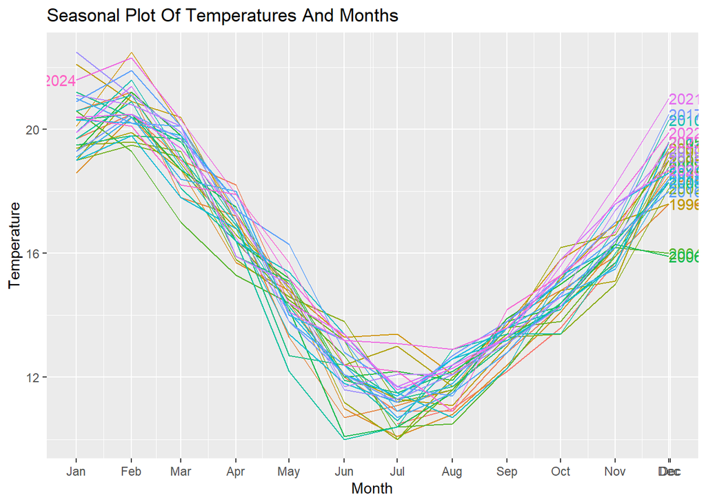

```r
auckland_temps %>%
  gg_season(Temperature, labels = "right") +
    labs(title = "Seasonal Plot Of Temperatures And Months")
```

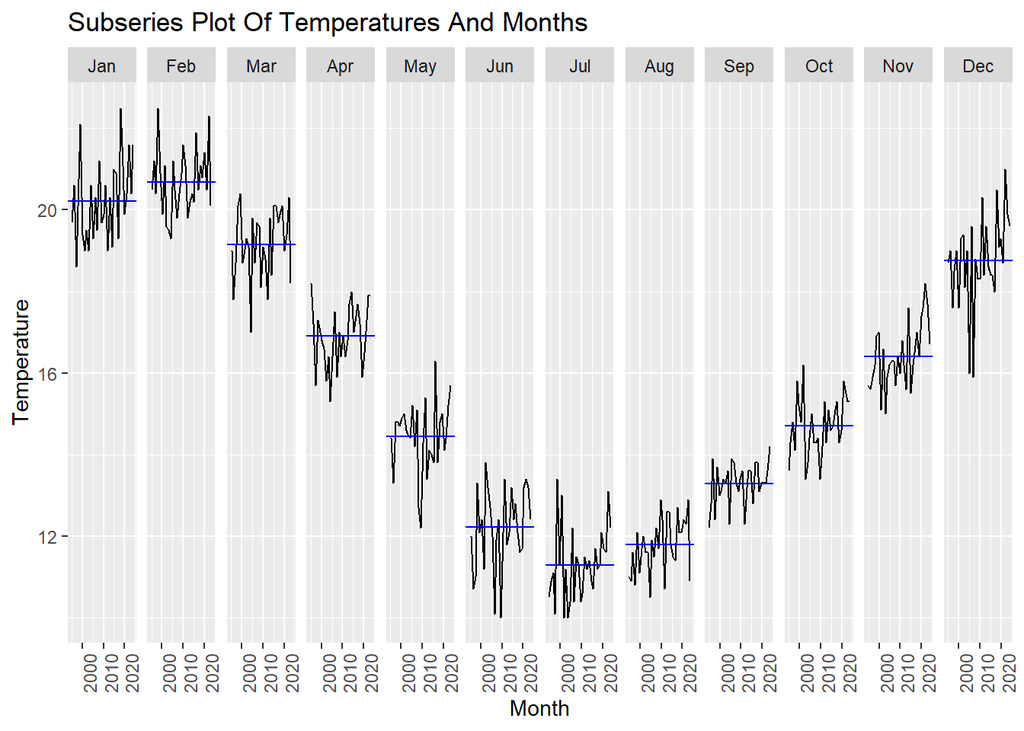

```r
auckland_temps %>%
  gg_subseries(Temperature) +
    labs(title = "Subseries Plot Of Temperatures And Months")
```

The first plot is a time plot that displays the value of the Auckland temperature based on years. The plot shows specific trends, cyclic patterns, and peaks that are specific to each year and month from the 1990s to the 2020s. Looking at the data, we can see some slight changes during the years, but there are no noticeable changes in the pattern or trend of the data, suggesting that over the years there have been some alternations in Auckland temperature but nothing outstanding enough based on the time plot. Therefore, we will need to look at the following plots to get a more defined idea of how the temperature has changed based on the seasonal patterns.

> 3. 8 Marks
> - Create a lag plot for the first 12 lags. Use the `point` geometry and set `alpha = 0.5`.
> - Write a sentence or two explaining what autocorrelation is.
> - Comment on the patterns you observe in the lag plot, explaining why we see these specific autocorrelation patterns for lags 1, 6, and 12.

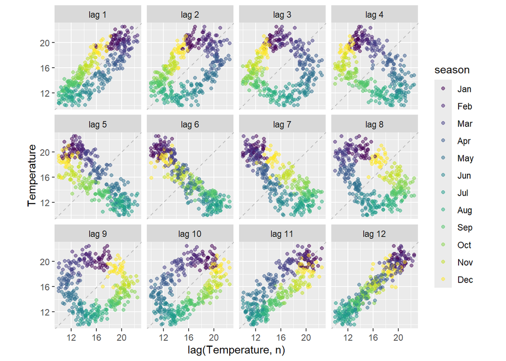

```r
auckland_temps %>%
  gg_lag(Temperature, lags = 1:12,  geom = "point", alpha = 0.5) +
  labs()
```

## Explanation And Interpretation Of Autocorelation And Specific Patterns In The Lag Plot Above:

Autocorrelation is a time series concept used to measure the patterns and the degree of correlation between certain values (primarily seasonality and cyclic patterns) over a specific period of time. In this case, a lag plot has been used as a tool to measure the lagged correlation of Auckland temperature in the 12 months of the year.

The months and other conditions in lags 1, 6, and 12 explain the autocorrelation presented. Lag numbers 12 and 1 both follow a similar positive linear trend, which is due to lag 12 being the same time as lag 1 but 12 months earlier, making the weather and seasonal situations very similar to lag number 1, causing the temperatures to be similar, while lag number 6 follows a negative linear correlation compared to both lag numbers 1 and 12, as there is a 6-month lag between lag numbers 6 and 1, causing the exact opposite correlation, which is probably due to it being a different time of the year where the weather, seasonal, and everything effectuating the temperatures to be different.

> 4. STATS 786 only 10 Marks
> - In this question, you will recreate the lag plot from (3).
> - Instead of using `gg_lag`, you will use functions from the `dplyr` and `ggplot2` packages to create your own lag plot. You may also need functions from `lubridate`, `forcats`, and `tidyr`.
> - Try to get your plot as close to the `gg_lag` plot you produced in (3). You will get full marks if your plot is exactly the same as what you get with `gg_lag`. Marks will be deducted for inconsistencies.
> - Note: There are many ways to solve this problem, but here are some things you may want to consider: how to create lagged variables in your data set, how to name them, how to convert your data set into a long format, and how to facet your plot.

> Total possible marks for **Problem 2**: 20 Marks for 326 30 Marks for 786

> Total possible marks for **Assignment 1**: 65 Marks for 326 75 Marks for 786